# EDA of the Gapminder Data

### Exercise 1: How would you work out the median life expectancy ? Hint `median` is the command needed to calculate a median.

Now let’s calculate the mean life expectancy in each continent. To do this we need to use the `group_by` command to tell R that we want summaries over a group variable (continent in this case).

```r
gapminder %>% group_by(continent) %>% summarise(mean.LifeExp=mean(lifeExp))
```

```
## # A tibble: 5 x 2
##   continent mean.LifeExp
##   <fct>            <dbl>
## 1 Africa            48.9
## 2 Americas          64.7
## 3 Asia              60.1
## 4 Europe            71.9
## 5 Oceania           74.3
```

### Exercise 2: How would you work out the median life expectancy for each continent ?

### Exercise 3: How would you work out the standard deviation in life expectancy for each continent ? Hint `sd` is the function needed to calculate the standard deviation.

### Exercise 4: Write a two line interpretation of your results of exercises 1, 2 and 3.

## Visualising the data

Let’s generate some plots of the data. There are many ways to plot data in R. One of the most popular is to use the ggplot2 package. This will be discussed in more detail in lectures and tutorials.

To plot your data using ggplot2, you specify three things:

1. Your data
2. Your aesthetics (for example, what’s on the x-axis)
3. Your layers (for example, barplot, scatterplot)

The first argument is the data you’re visualising. Next you define the `aes`thetic mappings. In other words, the columns of the data that get mapped to certain aesthetic features of the plot, e.g. the `x` axis will represent the variable called `x` and the `y` axis will represent the variable called `y`. Note that the aes() function is really a way to map the aesthetics of the plot to the variables in the data. See the Modern Dive book (by Chester Ismay & Albert Y. Kim) metioned on the course Blackboard page for more details.

Then we add another layer to this plot where we define which `geom`etric shapes we want to use to represent each observation in the data.

If this seems like a lot, it is. Don’t panic, you will learn about the philosophy of building data visualizations in more detail over the course and in future assignments. For now, follow along with the code that is provided.

First you’ll plot a boxplot of the life expectancy of each continent. The code is ‘read’ as follows: create a plot using the gapminder data , use continent as the aesthetic for the x-axis and life expectancy as the aesthetic for the y-axis, and and the shape I want to plot is a boxplot with certain labels for each axis.

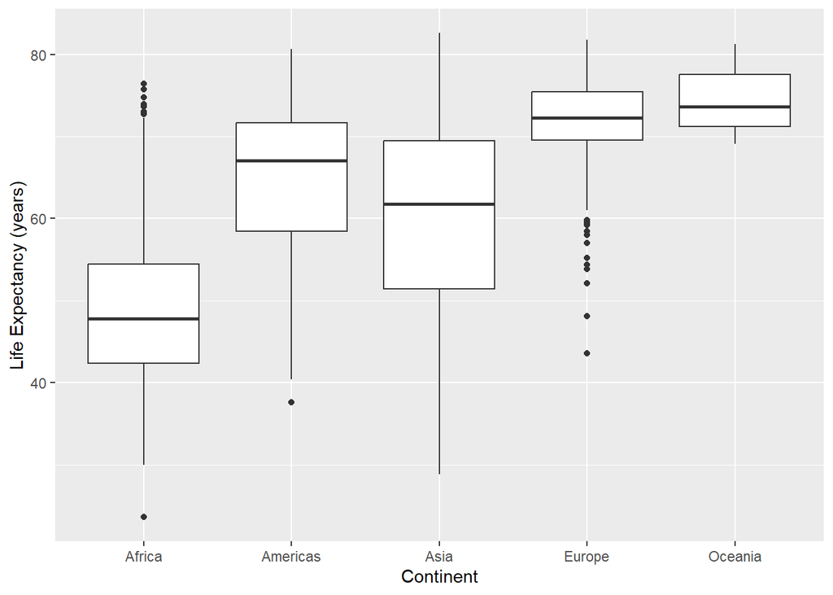

```r
ggplot(gapminder, aes(x = continent, y = lifeExp)) +
  geom_boxplot() +
  ylab("Life Expectancy (years)") +
  xlab("Continent")
```

### Exercise 5. Write a two line interpretation of this plot.

### Exercise 6. Create a boxplot of the GDP per capita variable (gdpPercap) and give an interpretation.

The next task is to investigate the relationship between the wealth of a country and its life expectancy (represented by the gdpPercap variable). This is best done using a simple scatterplot.

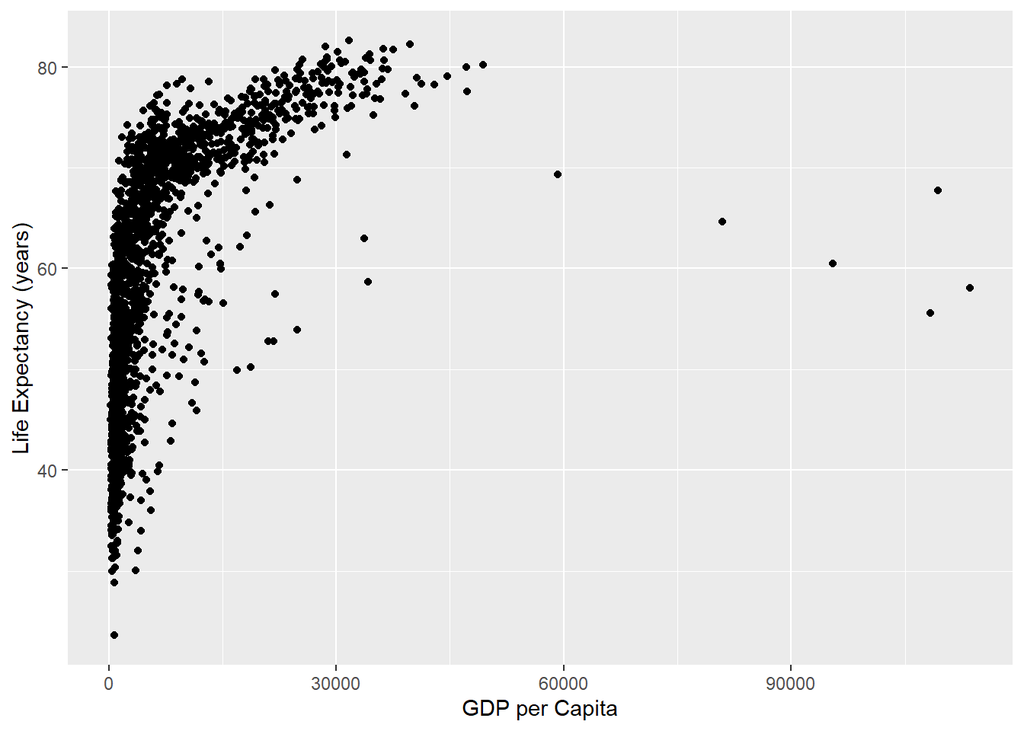

```r
ggplot(gapminder, aes(y = lifeExp, x = gdpPercap)) +
    geom_point() +
  ylab("Life Expectancy (years)") +
  xlab("GDP per Capita")
```

### Exercise 7. Interpret this plot.

Hans Rosling came up with a great idea which was to animate the scatterplot over time …. you will see this in class !

Save your work, knit your file as a word (or html) and save it. You will be asked to turn this in using Blackboard next week.

## extra bonus assignment

If you would like to try an extra task we will create a lineplot to see how life expectancy has changed over time for any chosen country. The first thing you need to do is to first filter out the data for the country in question and then pass this data into the plotting function.

You can read the code like a sentence: “start with the gapminder dataframe and then filter out all rows that contain Ireland in the country variable, then create a plot by mapping year to the x axis and life expectancy to the y axis, display all the data for a country in the same line and use a different colour for each country, adding a line on as the layer of the plot.” Note that the ‘%>%’ command is read as ‘then’ in the sequence of arguments while the ‘+’ is used by ggplot to add new components to the graph.

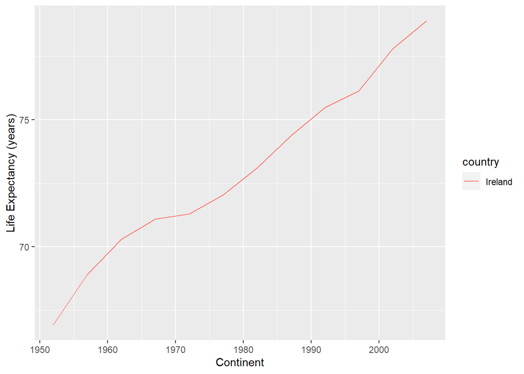

```r
gapminder %>% filter(country %in% c("Ireland")) %>%
  ggplot(aes(x = year, y = lifeExp, group=country, color=country)) +
  geom_line() +
  ylab("Life Expectancy (years)") +
  xlab("Continent")
```

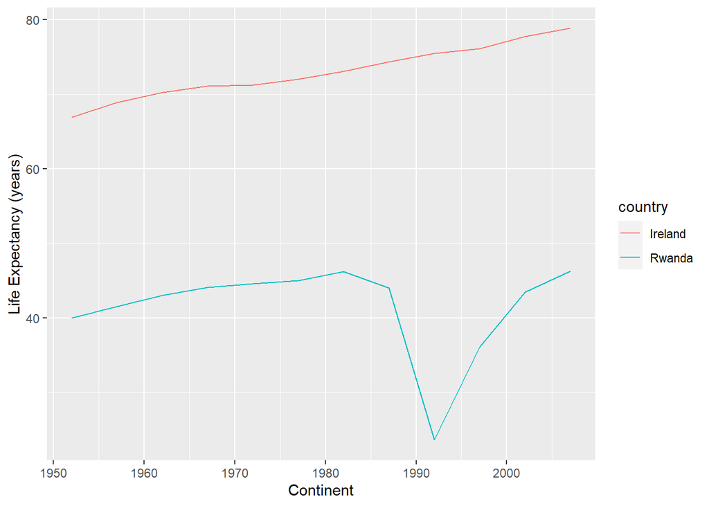

```r
gapminder %>% filter(country %in% c("Ireland", "Rwanda")) %>%
  ggplot(aes(x = year, y = lifeExp, group=country, color=country)) +
  geom_line() +
  ylab("Life Expectancy (years)") +
  xlab("Continent")
```

## Bonus Exercise 8.

Plot the life expectancy over time for any countries you like. To get the names of the countries you need to make a list of the countries in the dataset. YOu can do this as follows:

```r
gapminder %>% select(country) %>% table()
```

```
## .
##              Afghanistan                  Albania                  Algeria
##                       12                       12                       12
##                   Angola                Argentina                Australia
##                       12                       12                       12
##                  Austria                  Bahrain               Bangladesh
##                       12                       12                       12
##                  Belgium                    Benin                  Bolivia
##                       12                       12                       12
##   Bosnia and Herzegovina                 Botswana                   Brazil
##                       12                       12                       12
##                 Bulgaria             Burkina Faso                  Burundi
##                       12                       12                       12
##                 Cambodia                 Cameroon                   Canada
##                       12                       12                       12
## Central African Republic                     Chad                    Chile
##                       12                       12                       12
##                    China                 Colombia                  Comoros
##                       12                       12                       12
##         Congo, Dem. Rep.              Congo, Rep.               Costa Rica
##                       12                       12                       12
##            Cote d'Ivoire                  Croatia                     Cuba
##                       12                       12                       12
##           Czech Republic                  Denmark                 Djibouti
##                       12                       12                       12
##       Dominican Republic                  Ecuador                    Egypt
##                       12                       12                       12
##              El Salvador        Equatorial Guinea                  Eritrea
##                       12                       12                       12
##                 Ethiopia                  Finland                   France
##                       12                       12                       12
##                    Gabon                   Gambia                  Germany
##                       12                       12                       12
##                    Ghana                   Greece                Guatemala
##                       12                       12                       12
##                   Guinea            Guinea-Bissau                    Haiti
##                       12                       12                       12
##                 Honduras         Hong Kong, China                  Hungary
##                       12                       12                       12
##                  Iceland                    India                Indonesia
```

[output cut: 42 more lines]

```
##                       12                       12                       12
##              Switzerland                    Syria                   Taiwan
##                       12                       12                       12
##                 Tanzania                 Thailand                     Togo
##                       12                       12                       12
##      Trinidad and Tobago                  Tunisia                   Turkey
##                       12                       12                       12
##                   Uganda           United Kingdom            United States
##                       12                       12                       12
##                  Uruguay                Venezuela                  Vietnam
##                       12                       12                       12
##       West Bank and Gaza              Yemen, Rep.                   Zambia
##                       12                       12                       12
##                 Zimbabwe
##                       12
```

## Bonus exercise 9

Run the code below to create a plot of the life expectancy over time where data for each country are grouped togtehr (in order to get a seperate line for each country) and colour each coutry by the continent it comes from.

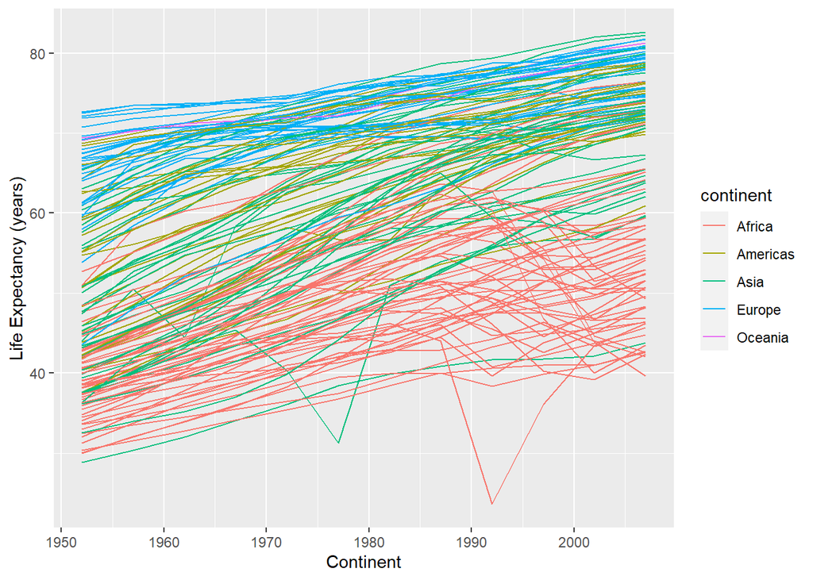

```r
ggplot(gapminder,aes(x = year, y = lifeExp, group=country, color=continent)) +
  geom_line() +
  ylab("Life Expectancy (years)") +
  xlab("Continent")
```

How would you find out the country (in Africa) that had low life expectancy in the early 1990s? Hint use the `arrange` function.